# TimeSeries

```r
library(forecast)
library(tseries)

data_path <- "time-series.csv"
data <- read.csv(data_path, header = TRUE, sep = '\t')
```

```r
dat1_ts <- ts(data$Dat1)
```

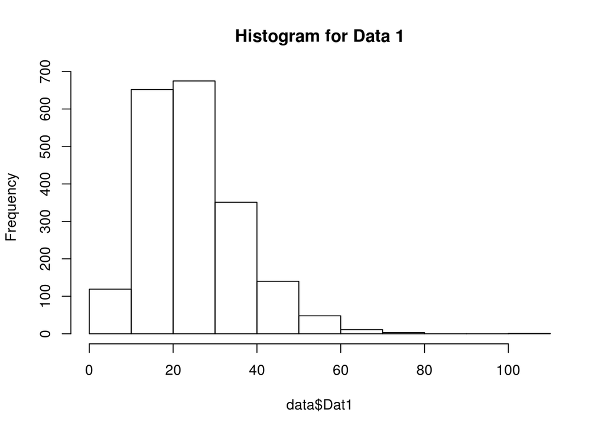

```r
hist(data$Dat1, main = "Histogram for Data 1")
```

Looks like random data (white noise) with no trend

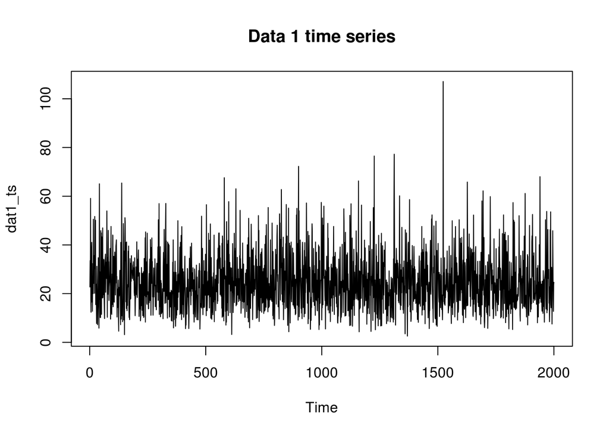

```r
plot(dat1_ts, main = "Data 1 time series")
```

No peaks in autocorrelation function (ACF) partial autocorrelation function (PACF) suggest that data does not depend on previous observations (stationary time series)

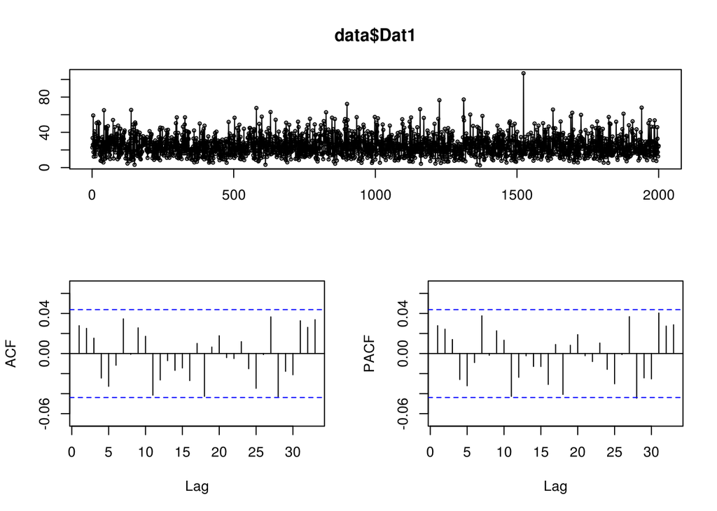

```r
tsdisplay(data$Dat1)
```

p-value for Dickey-Fuller suggest stationarity of the data

```r
adf.test(data$Dat1, alternative = c("stationary"))
```

```
##
##  Augmented Dickey-Fuller Test
##
## data:  data$Dat1
## Dickey-Fuller = -12.744, Lag order = 12, p-value = 0.01
## alternative hypothesis: stationary
```

KPSS Test

```r
kpss.test(data$Dat1)
```

```
##
##  KPSS Test for Level Stationarity
##
## data:  data$Dat1
## KPSS Level = 0.17265, Truncation lag parameter = 10, p-value = 0.1
```

Auto ARIMA selects ARIMA(0,0,0) model: 0 for ACF, PACF and 0 diffetials needed to make data stationary.

```r
dat1_mod_a <- auto.arima(dat1_ts)
summary(dat1_mod_a)
```

```
## Series: dat1_ts
## ARIMA(0,0,0) with non-zero mean
##
## Coefficients:
##       intercept
##         24.7781
## s.e.     0.2560
##
## sigma^2 estimated as 131.1:  log likelihood=-7713.8
## AIC=15431.6   AICc=15431.61   BIC=15442.8
##
## Training set error measures:
##                        ME     RMSE     MAE       MPE     MAPE      MASE
## Training set 5.613046e-13 11.44968 8.93299 -26.68381 48.87594 0.7254067
##                    ACF1
## Training set 0.02778337
```

Forecast selects just expected value and adds margin confidence and prediction intervals

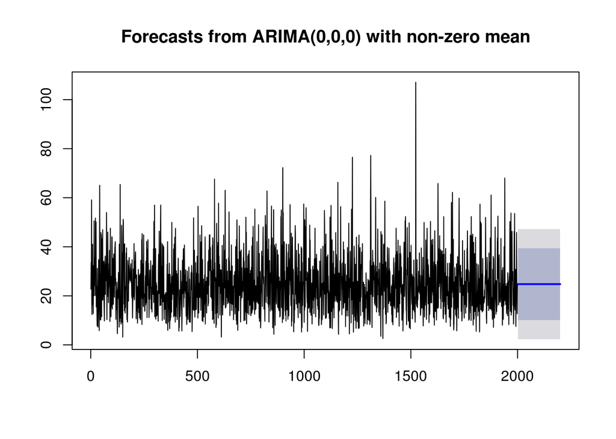

```r
forecast_1a <- forecast(dat1_mod_a, 200)
plot(forecast_1a)
```

From observations to observation’s growth for each next point (treating data as non stationary and trying to make it so for prediction)

```r
dat1_diff <- diff(data$Dat1)
```

Looks like previous value has effect in ACF and few previous values are valid for PACF

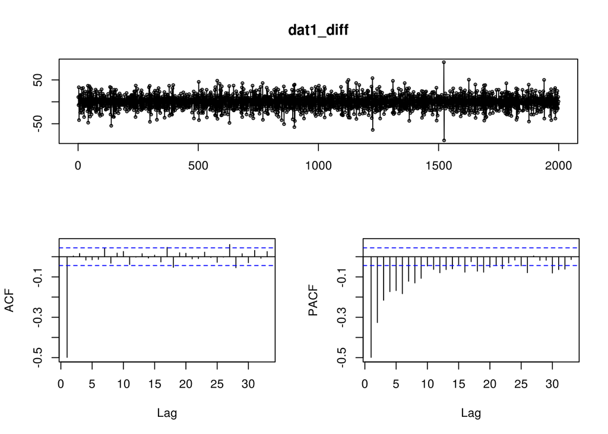

```r
tsdisplay(dat1_diff)
```

But coefficients for args are not significant (division < 1)

```r
dat1_diff_ts <- ts(dat1_diff)
dat1_diff_mod_a <- auto.arima(dat1_diff_ts)
summary(dat1_diff_mod_a)
```

```
## Series: dat1_diff_ts
## ARIMA(4,0,1) with zero mean
##
## Coefficients:
##           ar1     ar2     ar3      ar4      ma1
##       -0.0147  0.0168  0.0005  -0.0294  -0.9847
## s.e.   0.0220  0.0225  0.0224   0.0225   0.0042
##
## sigma^2 estimated as 132.7:  log likelihood=-7722.08
## AIC=15456.44   AICc=15456.48   BIC=15490.04
##
## Training set error measures:
##                     ME     RMSE     MAE  MPE MAPE      MASE       ACF1
## Training set 0.2019154 11.50786 8.94261 -Inf  Inf 0.4155021 0.04147224
```

Slowly decaying ACF suggests that data is not stationary Clear positive trend is visible

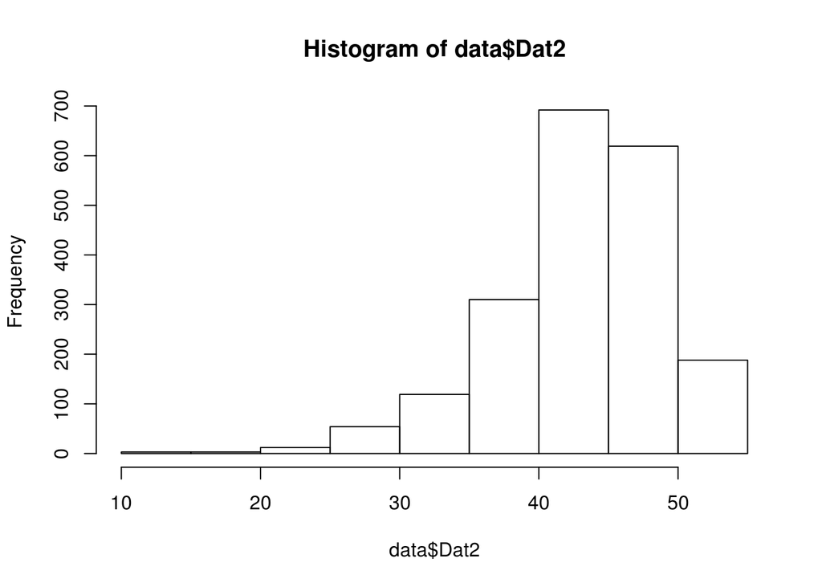

```r
hist(data$Dat2)
```

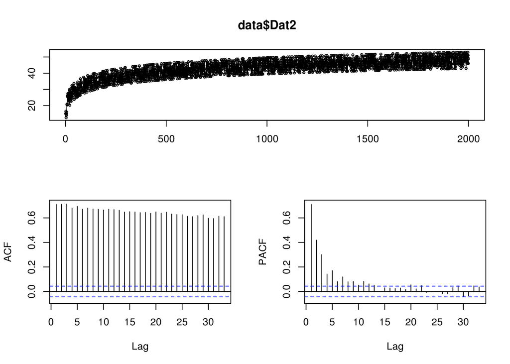

```r
#non-stationar data with trend, random walk
tsdisplay(data$Dat2)
```

```r
dat2 <- data$Dat2
```

First diff order to make data stationary

```r
dat2_diff <- diff(dat2)
```

Time series plot suggest stationarity. ACF and PACF show that value depends on previous values.

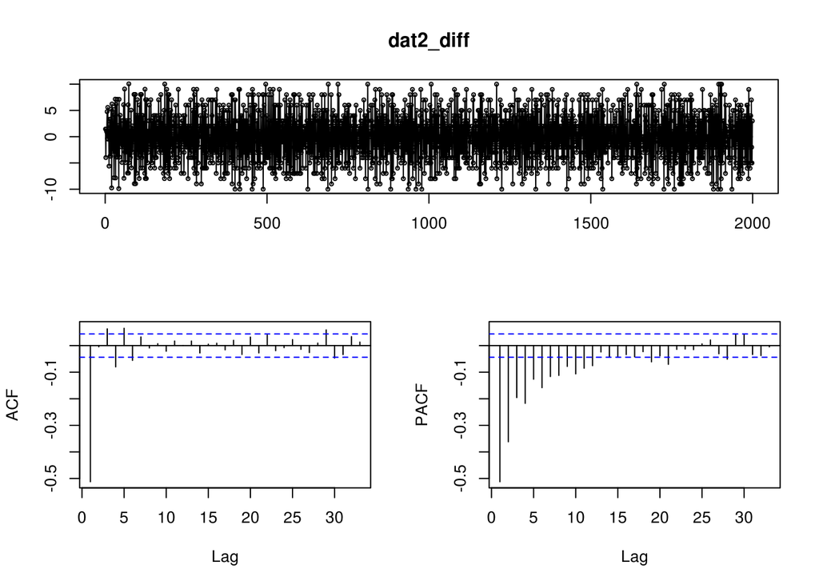

```r
tsdisplay(dat2_diff)
```

Stationarity hypothesis is rejected by Kwiatkowski-Phillips-Schmidt-Shin test

```r
dat2_ts <- ts(dat2)
adf.test(dat2, alternative = c("stationary"))
```

```
##
##  Augmented Dickey-Fuller Test
##
## data:  dat2
## Dickey-Fuller = -6.5629, Lag order = 12, p-value = 0.01
## alternative hypothesis: stationary
```

```r
kpss.test(dat2)
```

```
##
##  KPSS Test for Level Stationarity
##
## data:  dat2
## KPSS Level = 13.861, Truncation lag parameter = 10, p-value = 0.01
```

Auto ARIMA selects (1,1,2) model. Drift coef 1 suggests that diff was required. All coef non zero - they are significant, drift 0.0138 suggests removed positive trend

```r
dat2_mod_a <- auto.arima(dat2_ts)
summary(dat2_mod_a)
```

```
## Series: dat2_ts
## ARIMA(1,1,2) with drift
##
## Coefficients:
##          ar1      ma1     ma2   drift
##       0.8998  -1.8487  0.8551  0.0138
## s.e.  0.0717   0.0749  0.0712  0.0047
##
## sigma^2 estimated as 10.35:  log likelihood=-5173.29
## AIC=10356.59   AICc=10356.62   BIC=10384.59
##
## Training set error measures:
##                      ME     RMSE      MAE        MPE     MAPE      MASE
## Training set 0.02963072 3.216224 2.759333 -0.3161546 6.599366 0.7651513
##                      ACF1
## Training set -0.005400145
```

Forecast for 100 values shows future positive trend

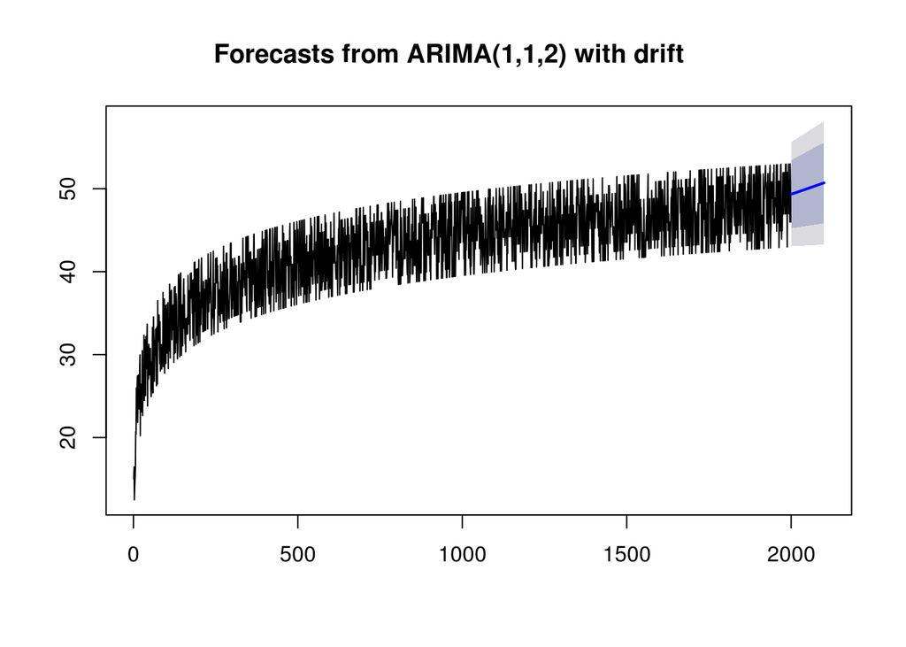

```r
forecast_2a <- forecast(dat2_mod_a, 100)
plot(forecast_2a)
```

Same for neural networks prediction

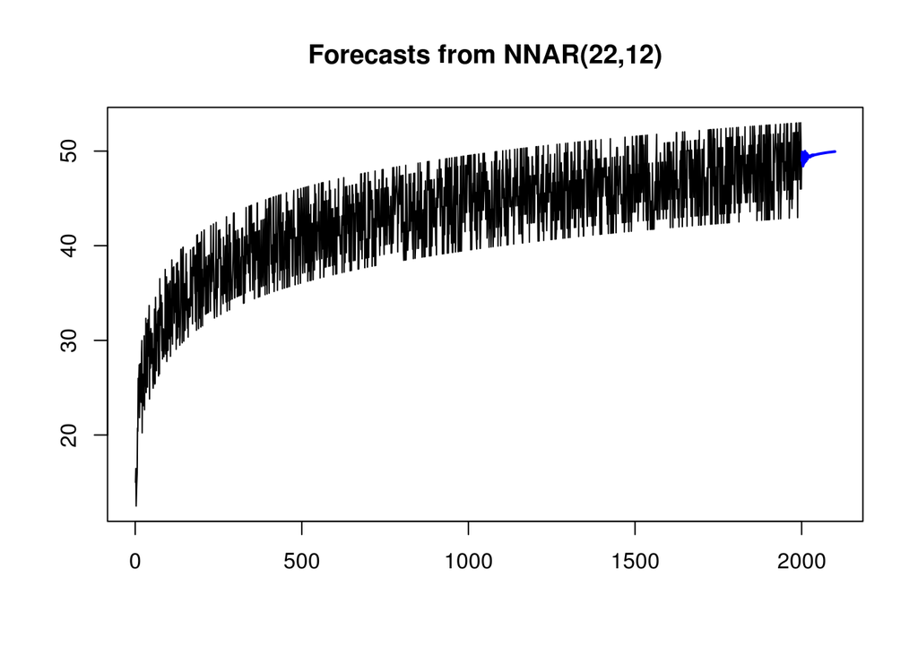

```r
nn_fit <- nnetar(dat2)
plot(forecast(nn_fit, 100))
```